# Week2_T_test

Alexander Frieden

January 9, 2016

In this we are going to be looking to use the T test to work with. As we have previously described, the T test is a statistical tool that is used to see if two data sets are statistically different from one another and is used when the test statistic follows roughly a normal distribution. Another way of saying this is to see if two means are reliably different from each other.

For example:

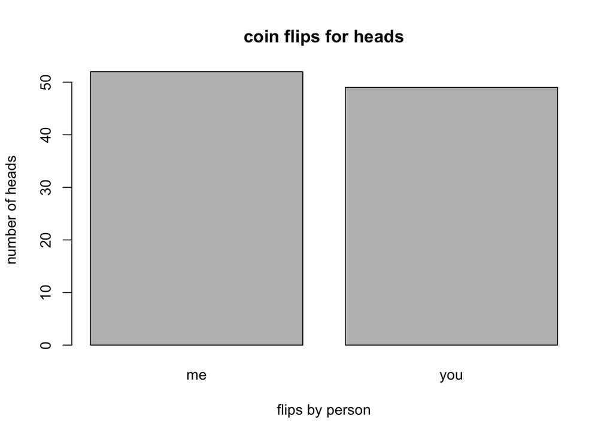

```r
cars <- c(52,49)
barplot(cars, main="coin flips for heads",names=c("me","you"),xlab="flips by person",ylab="number of heads")
```

Each T test has a corresponding P value. This P value is the probability that the pattern of data in the sample could be produced by random data. If the p value is 0.5, then that means there is a 5% chance there is no real difference. In general, we only accept p = 0.5 as being reliable.

Exact p value depends on the sample size. The p-value for each t-value also depends on the sample size. Bigger samples make it easier to detect differences.

Example: A company that manufactures light bulbs claims that a particular type of light bulb will last 850 hours on average with standard deviation of 50. A consumer protection group thinks that the manufacturer has overestimated the lifespan of their light bulbs by about 40 hours. How many light bulbs does the consumer protection group have to test in order to prove their point with reasonable confidence?